# Algoritma Academy: Time Series & Forecasting

### 2.2.1 Mathematical details of Time Series Decomposition

The `SMA` function in R calculates various moving averages (MA) of a series, but only do so by averaging over past *n* observations - which is **not** the moving average model that our classical decomposition uses. When you do a simple moving average on the original time series using `SMA`, you’ll set `n` to be the number of past observations over which an average is computed.

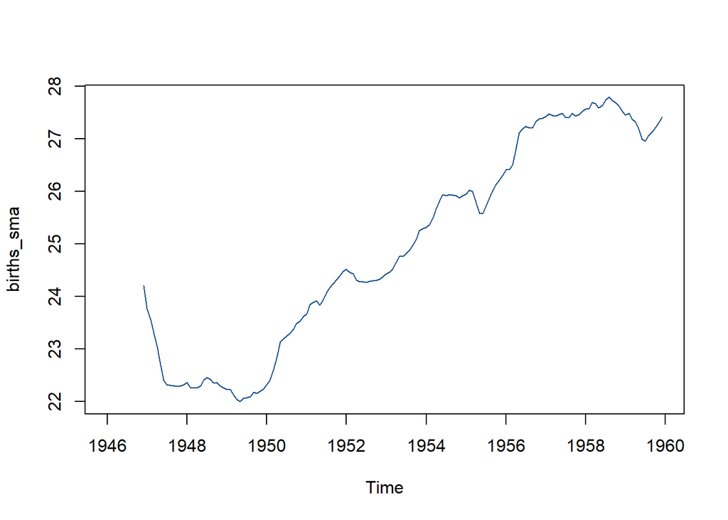

```r
library(TTR)
births_sma <- SMA(births_ts, n = frequency(births_ts))
plot.ts(births_sma, col="dodgerblue4")
```

So to solidify our understanding of the classical decomposition process, let’s study the mathematical details behind `decompose()` by comparing our manual calculation to the one we obtain from `decompose`.

When we estimate the Trend component from a time series by using a moving average, recall that the specification is to have a symmetric window with equal weights. For a time series with 12 as the frequency value, the weight assigned to each observations within that considered window would be the same:

```r
c(0.5, rep_len(1, 12-1), 0.5)/12
```

```
##  [1] 0.04166667 0.08333333 0.08333333 0.08333333 0.08333333 0.08333333
##  [7] 0.08333333 0.08333333 0.08333333 0.08333333 0.08333333 0.08333333
## [13] 0.04166667
```

That applies to a frequency with an even number, so both sides to the point are equally considered. If frequency was an odd number, the calculation of weight is more straightforward:

```r
frq <- 7
rep_len(1, frq)/frq
```

```
## [1] 0.1428571 0.1428571 0.1428571 0.1428571 0.1428571 0.1428571 0.1428571
```

Using the weights above, we can now calculate the moving average of observation #7. The first and last value is the considered window is assigned a weight of 0.04166667, and other points are given equal weight:

```r
sum(
as.vector(births_ts[1])*0.04166667,
as.vector(births_ts[2:12])*0.08333333,
as.vector(births_ts[13])*0.04166667
)
```

```
## [1] 23.98433
```

To calculate the moving average of observation #8, we move the considered window by one unit of time to the right and then apply the weight similarly to the above:

```r
sum(
as.vector(births_ts[2])*0.04166667,
as.vector(births_ts[3:13])*0.08333333,
as.vector(births_ts[14])*0.04166667
)
```

```
## [1] 23.66212
```

If that seems tedious, the good news is that we can make use of the `filter()` function which by default apply our weights / coefficients to both sides of the point. Observe that the result for observation 7 and 8 is the equivalent to our manual calculation above:

```r
coef1 <- c(0.5, rep_len(1, frequency(births_ts)-1), 0.5)/frequency(births_ts)
trn <- stats::filter(births_ts, coef1)
trn
```

```
##           Jan      Feb      Mar      Apr      May      Jun      Jul      Aug
## 1946       NA       NA       NA       NA       NA       NA 23.98433 23.66213
## 1947 22.35350 22.30871 22.30258 22.29479 22.29354 22.30562 22.33483 22.31167
## 1948 22.43038 22.43667 22.38721 22.35242 22.32458 22.27458 22.23754 22.21988
## 1949 22.06375 22.08033 22.13317 22.16604 22.17542 22.21342 22.27625 22.35750
## 1950 23.21663 23.26967 23.33492 23.42679 23.50638 23.57017 23.63888 23.75713
## 1951 24.00083 24.12350 24.20917 24.28208 24.35450 24.43242 24.49496 24.48379
## 1952 24.27204 24.27300 24.28942 24.30129 24.31325 24.35175 24.40558 24.44475
## 1953 24.78646 24.84992 24.92692 25.02362 25.16308 25.26963 25.30154 25.34125
## 1954 25.92446 25.92317 25.92967 25.92137 25.89567 25.89458 25.92963 25.98246
## 1955 25.64612 25.78679 25.93192 26.06388 26.16329 26.25388 26.35471 26.40496
## 1956 27.21104 27.21900 27.20700 27.26925 27.35050 27.37983 27.39975 27.44150
## 1957 27.44221 27.40283 27.44300 27.45717 27.44429 27.48975 27.54354 27.56933
## 1958 27.68642 27.76067 27.75963 27.71037 27.65783 27.58125 27.49075 27.46183
## 1959 26.96858 27.00512 27.09250 27.17263 27.26208 27.36033       NA       NA
##           Sep      Oct      Nov      Dec
## 1946 23.42333 23.16112 22.86425 22.54521
## 1947 22.26279 22.25796 22.27767 22.35400
## 1948 22.16983 22.07721 22.01396 22.02604
## 1949 22.48862 22.70992 22.98563 23.16346
## 1950 23.86354 23.89533 23.87342 23.88150
## 1951 24.43879 24.36829 24.29192 24.27642
## 1952 24.49325 24.58517 24.70429 24.76017
## 1953 25.42779 25.57588 25.73904 25.87513
## 1954 26.01054 25.88617 25.67087 25.57312
## 1955 26.45379 26.64933 26.95183 27.14683
## 1956 27.45229 27.43354 27.44488 27.46996
## 1957 27.63167 27.67804 27.62579 27.61212
## 1958 27.42262 27.34175 27.25129 27.08558
## 1959       NA       NA       NA       NA
```

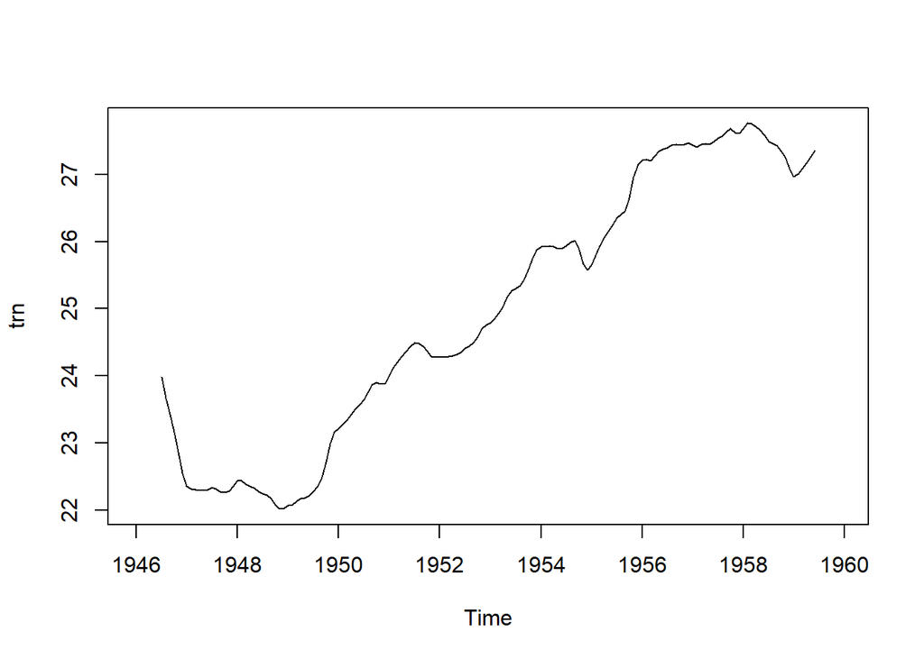

```r
plot(trn)
```

Compare the figures you’ve arrived at manually to the trend component output from the `decompose()` function. They are the same.

Now that we know how to arrive manually at the values of our Trend component, let’s see how we arrive at the Seasonal component of the time series. Recall that the frequency of our time series is 12, and we will use that to create a sequence consisting of the multiples of 12. Informally, we are going to take the average of the values in this sequence later, add 1 to each value in the sequence and again record the average, then add 1 again - and repeat this 12 times so we end up with a series of length 12, each being the mean of the values in each iteration.

```r
f <- frequency(births_ts)
index <- seq.int(1L, length(births_ts), by = f) - 1L
index
```

```
##  [1]   0  12  24  36  48  60  72  84  96 108 120 132 144 156
```

Formally, here’s the code to do it:

```r
prd <- length(births_ts)/frequency(births_ts)
# if multiplicative: birth_ts/births_dc$trend
detrend <- births_ts - births_dc$trend

# initialize figure to 0 0 0 0 0 ... 0 (12 times)
figure <- numeric(f)

for (i in 1L:f)
      figure[i] <- mean(detrend[index + i], na.rm = TRUE)

# if multiplicative: figure / mean(figure)
figure <- figure - mean(figure)

ssnl <- ts(rep(figure, prd + 1)[seq_len(length(births_ts))], start = start(births_ts), frequency = f)
ssnl
```

```
##             Jan        Feb        Mar        Apr        May        Jun
## 1946 -0.6771947 -2.0829607  0.8625232 -0.8016787  0.2516514 -0.1532556
## 1947 -0.6771947 -2.0829607  0.8625232 -0.8016787  0.2516514 -0.1532556
## 1948 -0.6771947 -2.0829607  0.8625232 -0.8016787  0.2516514 -0.1532556
## 1949 -0.6771947 -2.0829607  0.8625232 -0.8016787  0.2516514 -0.1532556
## 1950 -0.6771947 -2.0829607  0.8625232 -0.8016787  0.2516514 -0.1532556
## 1951 -0.6771947 -2.0829607  0.8625232 -0.8016787  0.2516514 -0.1532556
## 1952 -0.6771947 -2.0829607  0.8625232 -0.8016787  0.2516514 -0.1532556
## 1953 -0.6771947 -2.0829607  0.8625232 -0.8016787  0.2516514 -0.1532556
## 1954 -0.6771947 -2.0829607  0.8625232 -0.8016787  0.2516514 -0.1532556
## 1955 -0.6771947 -2.0829607  0.8625232 -0.8016787  0.2516514 -0.1532556
## 1956 -0.6771947 -2.0829607  0.8625232 -0.8016787  0.2516514 -0.1532556
## 1957 -0.6771947 -2.0829607  0.8625232 -0.8016787  0.2516514 -0.1532556
## 1958 -0.6771947 -2.0829607  0.8625232 -0.8016787  0.2516514 -0.1532556
## 1959 -0.6771947 -2.0829607  0.8625232 -0.8016787  0.2516514 -0.1532556
##             Jul        Aug        Sep        Oct        Nov        Dec
## 1946  1.4560457  1.1645938  0.6916162  0.7752444 -1.1097652 -0.3768197
## 1947  1.4560457  1.1645938  0.6916162  0.7752444 -1.1097652 -0.3768197
## 1948  1.4560457  1.1645938  0.6916162  0.7752444 -1.1097652 -0.3768197
## 1949  1.4560457  1.1645938  0.6916162  0.7752444 -1.1097652 -0.3768197
## 1950  1.4560457  1.1645938  0.6916162  0.7752444 -1.1097652 -0.3768197
## 1951  1.4560457  1.1645938  0.6916162  0.7752444 -1.1097652 -0.3768197
## 1952  1.4560457  1.1645938  0.6916162  0.7752444 -1.1097652 -0.3768197
## 1953  1.4560457  1.1645938  0.6916162  0.7752444 -1.1097652 -0.3768197
## 1954  1.4560457  1.1645938  0.6916162  0.7752444 -1.1097652 -0.3768197
## 1955  1.4560457  1.1645938  0.6916162  0.7752444 -1.1097652 -0.3768197
## 1956  1.4560457  1.1645938  0.6916162  0.7752444 -1.1097652 -0.3768197
## 1957  1.4560457  1.1645938  0.6916162  0.7752444 -1.1097652 -0.3768197
## 1958  1.4560457  1.1645938  0.6916162  0.7752444 -1.1097652 -0.3768197
## 1959  1.4560457  1.1645938  0.6916162  0.7752444 -1.1097652 -0.3768197
```

**Discussion:** 1. Compare the above to the seasonal component that our decomposition function returned. Are they identical?

2. Using `births_ts`, `trn` and `ssnl`, can you estimate the random components in our time series? `trn` and `ssnl` are the components we calculated by hand, and we already confirmed in earlier exercises that they are the same as the outputs from the classical decomposition function built-in with R.
3. I’ve read the following data and save it to an object named `souvenir`. Create a time series using the data above and name it `souvenir_ts`.

```r
souvenir <- scan("data_input/fancy.dat")
souvenir_ts <- ts(souvenir, frequency = 12, start = c(1987,1))
```

Plot the time series. Can you tell if an additive model is appropriate for this time series?

Write your solution for (Q3) below:

### 2.2.2 Seasonally Adjusting our time series

The following code plots a time series from our data, `fancy.dat`:

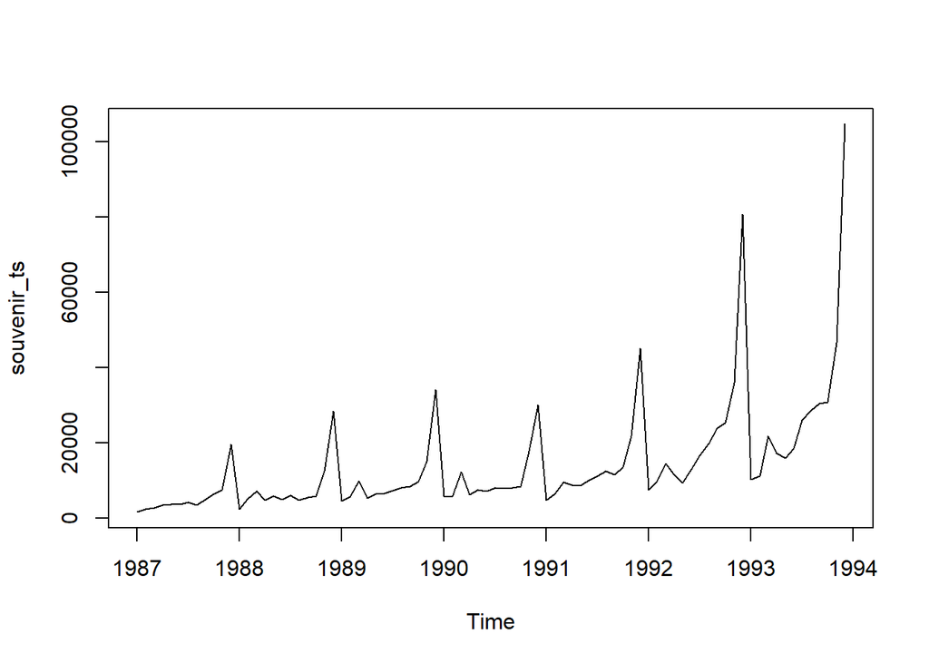

```r
souvenir <- scan("data_input/fancy.dat", quiet = T)
souvenir_ts <- ts(souvenir, frequency = 12, start = c(1987,1))
plot.ts(souvenir_ts)
```

In this case it appears an additive model is not appropriate for describing this time series, since both **the size of the seasonal fluctuations and size of the random fluctuations seem to increase** with the level of the time series. Thus, we may need to transform the time series and get a transformed time series that can be described using an additive model:

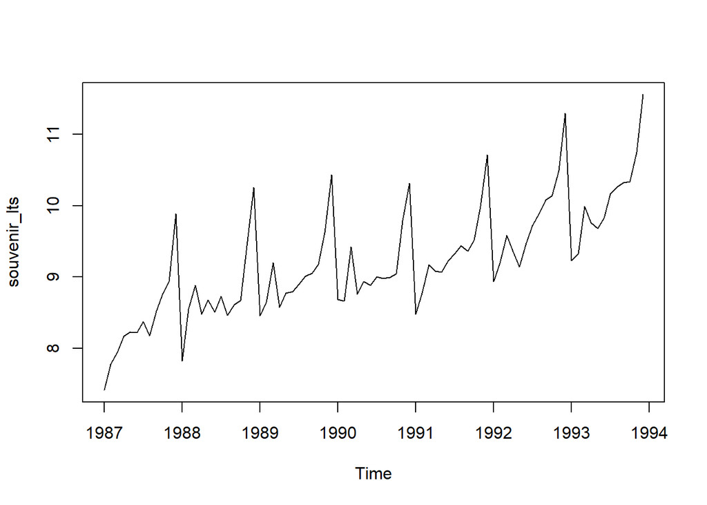

```r
souvenir_lts <- log(souvenir_ts)
plot.ts(souvenir_lts)
```

Now observe that **the size of the seasonal fluctuations and random fluctuations in the log-transformed time series are roughly constant** and no longer dependent on the level of the time series. This log-transformed time series can better be described by an additive model. We still observe seasonal fluctuations in our data due to the seasonal components, but what if we observe the sales trend after having it adjusted for the seasonality effect? Would it still be generally upward-trending, or is our optimism unwarranted?

The following code first decompose the log-transformed time series, and then remove the seasonal component from the time series. We can see that, having adjusted for seasonality our sales have still seen an upward-rising trend:

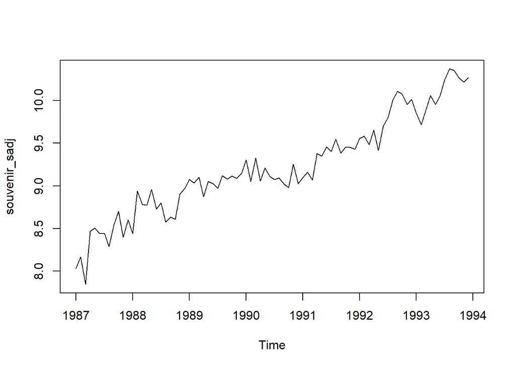

```r
souvenir_dc <- decompose(souvenir_lts)
souvenir_sadj <- souvenir_lts - souvenir_dc$seasonal
plot(souvenir_sadj)
```

So far we’ve been working with time series data with a seasonality component. In the following sub-section, let’s take a look at how we can work with non-seasonal data.

### 2.2.3 Decomposing Non-Seasonal Time Series

Decomposing a non-seasonal time series means separating the time series into the trend component and the irregular (random) component. To estimate the trend component of a non-seasonal time series that can be described using an additive model, it is common to use a smoothing method, such as calculating the simple moving average of the time series.

The `SMA()` function in the `TTR` package that we learn earlier can be used to smooth time series data using a simple moving average; Otherwise, you can also use the `filter()` function to apply a two-sided moving average. To see an example, consider the gas emissions in Indonesia data and observe how we first apply our `SMA()` function before plotting the time series:

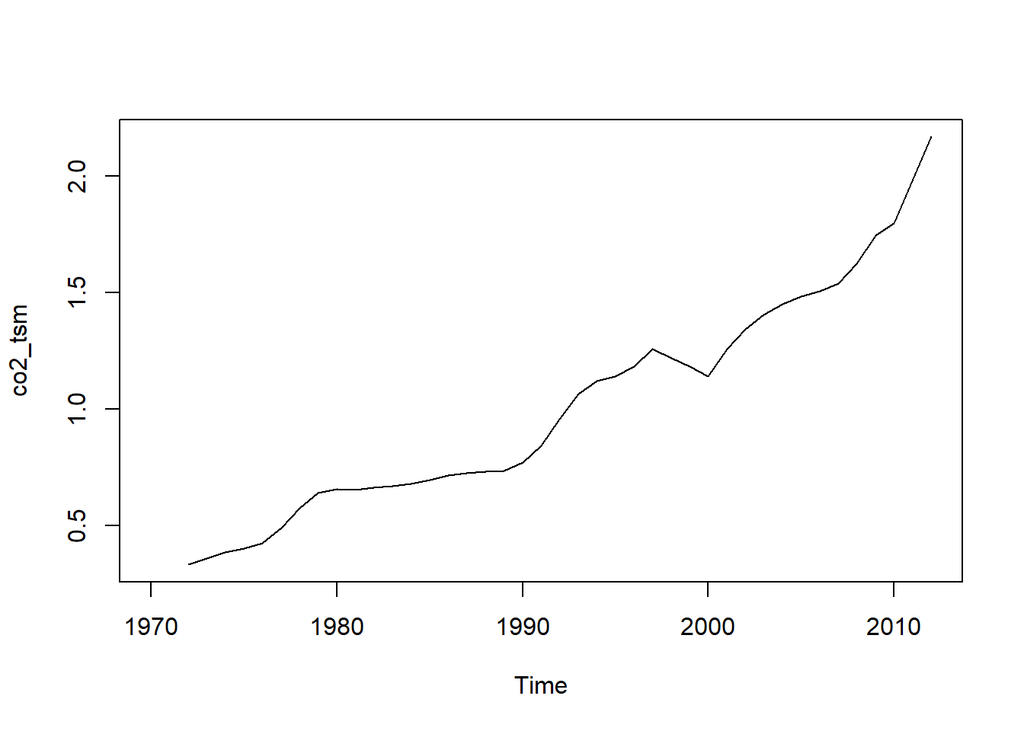

```r
library(TTR)
co2_tsm <- SMA(co2_ts, n=3)
plot(co2_tsm)
```

There still appears to be some random fluctuations with a simple moving average of order 3. To estimate the trend component more accurately, we may want to use smoothing with a higher order:

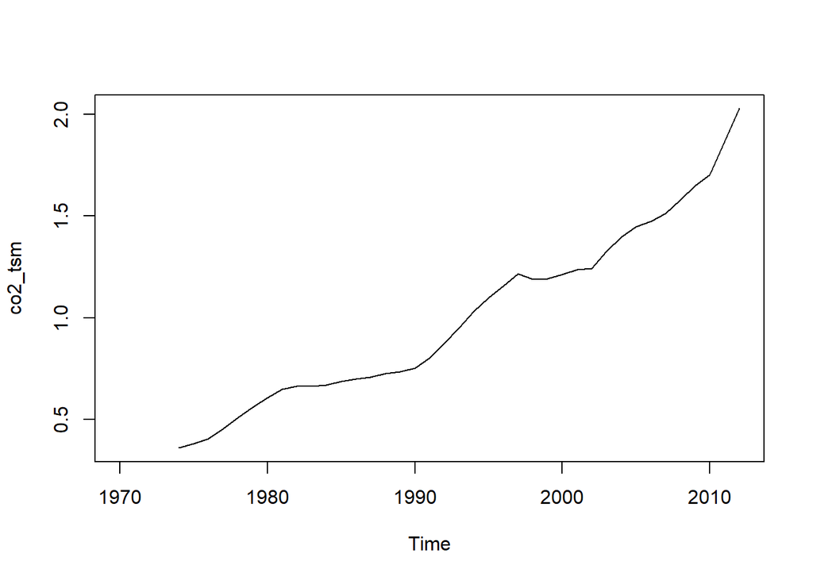

```r
co2_tsm <- SMA(co2_ts, n=5)
plot(co2_tsm)
```

The data smoothed with a simple moving average of order 5 gives a clearer picture of the trend component, and we can see that the level of co2 emissions contributed to Indonesia’s atmosphere have risen rather sharply in the more recent years (2005-2012). The increase was much sharper than in the past, say in the 20 years between 1970 to 1990.

As a reminder, recall that `SMA` calculates the arithmetic mean of the series over the past n observations. This is essentially a **one-sided moving average** and can be represented in the following form: $z_t = \frac{1}{k+1} \sum\limits^{k}_{j=0} y_{t-j}$

Compare this to a two-sided moving average which takes the form of: $z_t = \frac{1}{2k+1} \sum\limits^{k}_{j=-k} y_{t+j}$

Where *k* is the number of observations to consider in your moving average window and *t* is the observation we’re replacing with a moving average.

## 2.3 Forecasts using Simple Moving Average

When we apply the simple moving average method we’ve just learned above on future values of our time series, we’re essentially performing a forecasting using a rather simplistic method. The value of $y_{t+1}$ is estimated by taking the average of the past 5 values $y_{t-4} + ... + y_{t}$, and then subsequently $y_{t+2}$ is estimated by taking the average of $y_{t-3} + ... + y_{t+1}$ etc.

```r
future1 <- mean(tail(co2_ts, 5))
future2 <- mean(tail(co2_ts, 4), future1)
future3 <- mean(tail(co2_ts, 3), future1, future2)
future1; future2;
```

```
## [1] 2.027895
```

```
## [1] 2.099375
```

And if we were to plot our observation, along with the simple moving average (+3 future points) then we have a forecast model (even though a simple one!):

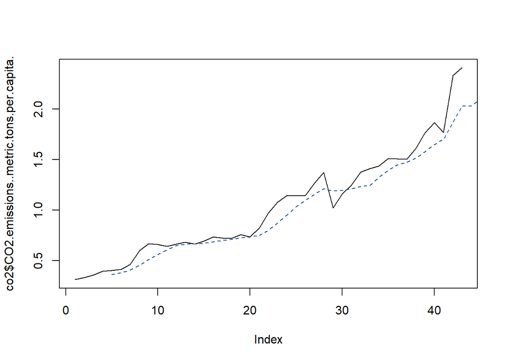

```r
plot(co2$CO2.emissions..metric.tons.per.capita., type="l")
co2_sma <- SMA(co2_ts, n=5)
lines(c(co2_sma, future1, future2, future3), col="dodgerblue4", lty=2)
```

### 2.3.1 Theoretical Considerations with a SMA Forecast

I get asked sometimes on when a simple moving average would suffice as a forecasting model, and I like to use that as an opportunity to help the student think about forecasting in general. If I present to you a constant mean model and tell you that the best estimate of tomorrow’s oil prices is the average of oil prices throughout history (since the existence of the stock market), you would argue that it is unlikely to be a good estimate because a lot of the history should have been ignored in the forecast as they play no role in the oil prices of tomorrow. What we just described is sometimes the **mean model** or the **constant model**[^7]. Oversimplistic as it may sound, that is a reasonable model if the values we’re predicting are independently and identically distributed.

Intuitively, you’ve shown an understanding that some of the very-distant past isn’t likely to help in our particular forecasting problem, and what matters tomorrow can better be estimated using a window of the more recent past - that is the basis of a SMA model. This model works best on time series with an almost-constant or slowly (but non-systematically) changing mean because of the underlying calculation (refer to above subsection). If the mean is almost constant, choosing *n* to be the total number of observations, hence using the full dataset, will give us the best estimate of a future value. Naturally, a longer observation period will average out the fluctuations and reduce the effect of variability.

Why do we assume that the changes are non-systematic? Because if there was any systematic changes in our mean, it would have been attributed to the seasonal or trend component and we wouldn’t have flatly used the mean as a forecast.

Another reasonable strategy you may propose is to weigh our observations such that recent observations have a stronger say in determining the future value than observations in the distant past. This brings us to the exponential smoothing method of forecasting in the next chapter.

## 2.4 Forecasts using Exponential Smoothing

When we have a time series that can be described using an additive model with an almost-constant mean level and no seasonality, you can also use simple exponential smoothing to make short-term forecasts. Exponential smoothing is named such because it “smooths” the weight of our past values as it estimate the value at each point in the time series. The degree of smoothing is controlled by the parameter $\alpha$, which takes a value of range 0 to 1. When alpha is equal to 1, only the most recent last observation is used as it tries to estimate the next successive value in the series.

The following data `precip1.dat`[^8] contains a series of total annual rainfall in inches for London, from 1813-1912 (original data from Hipel and McLeod, 1994).

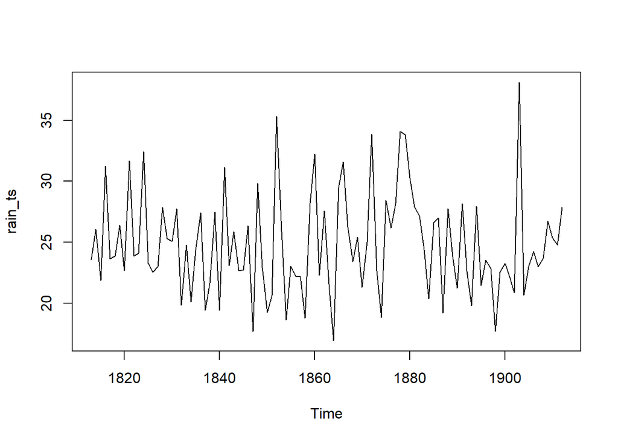

```r
rain <- scan("data_input/precip1.dat", skip=1)
rain_ts <- ts(rain, start=c(1813))
plot(rain_ts)
```

Observe that the mean hovers around 25 inches rather constantly throughout the 100 years and the random fluctuations also seem to be roughly constant in size, so it’s probably appropriate to describe the data using an additive model. We’ve seen how a SMA would have worked on the above time series but here we’ll see if a simple exponential smoothing algorithm is up to the task.

### 2.4.1 Comparison to SMA

Conceptually, where a single moving average assigns equal weight to *n* number of past observations, exponential smoothing assigns *exponentially decreasing weights* as the observation gets older and commonly consider the full data. Through the assignment of weights, we can then set our forecast to be more or less influenced by recent observations as compared to older observations.

In most cases an alpha parameter smaller than 0.40 is often effective. However, one may perform a grid search of the parameter space, with = 0.1 to = 0.9, with increments of 0.1. Then the best alpha has the smallest Mean Absolute Error (MA Error).

### 2.4.2 Comparison to the naive method & average method

Using the naive method, all forecasts for the future are equal to the last observed value of the series: $\hat{y}_{T+h|T} = y_T$

Because the naive method assumes that the most current observation is the only important one and all previous observations provide no information for the future, this can be thought of as a weighted average where all the weight is given to the last observation.

Using the average method, all observations are assumed to have equal important and given equal weight when generating forecasts.

We often want something between these two extremes, and one approach would be to assign heavier weights to more recent observations than to the distant ones. Using this approach, weights decrease exponentially leading to the smallest weights being assigned to the oldest observations:  
$\hat{y}_{T+1|T} = \alpha{y}_T + \alpha(1-\alpha)y_{T-1} + \alpha(1-\alpha)^2y_{T-2} + ...,$

The one-step-ahead forecast for time *T+1* is a weighted average of all the observations in the series $y_1 ... y_T$. The rate at which the weights decrease is controlled by the parameter alpha.

For any $\alpha$ between 0 and 1 (not including 0), the weights attached to the observations decrease exponentially as we go back in time, hence the name “exponential smoothing”. If $\alpha$ is small (i.e, close to 0), more weight is given to observations from the more distant past. If $\alpha$ is large (i.e, close to 1), more weight is given to the more recent observations. At the extreme case where $\alpha =1$, $\hat{y}_{T+1|T} = y_{T}$ and forecasts are equal to the naive forecasts. In other words: - $\alpha=1$: past values have no influence over forecasts (under-smoothing)  
- $\alpha \approx 0$: past values have equal influence over forecasts (over-smoothing)

Recall that the formula for the simple exponential smoothing: $\hat{y}_{T+1|T} = \alpha{y}_T + \alpha(1-\alpha)y_{T-1} + \alpha(1-\alpha)^2y_{T-2} + ...,$

### 2.4.3 SES as an adaptive learning process

If we vectorize the original equation, and use $L_t$ to denote the “level” at time *t* we can represent the level updating equation as: $L_t= \alpha Y_t + (1-a)L_{t-1} = a Y_t + L_{t-1} - \alpha L_{t-1}$

Which is equivalent to:  
$F_{t+1} = L_t = L_{t-1} + \alpha(Y_t - L_{t-1})$  
$F_{t+1} = L_t = F_t + \alpha(Y_t - F_t)$  
$F_{t+1} = L_t = F_t + \alpha * e_t$

This last form is simple and useful: it means that to forecast the next time period we update the previous forecast by an amount that depends on the error of the previous forecast. Another great benefit is that while our forecasts use all previous values, we really only need to store the most recent forecast and its error.

Let’s see how exponential smoothing works

The function I use here is `ets()`, which accepts an optional `model` specification and an alpha value of 0.2. The `model` is specified through a three-character string, where:  
- First letter denotes the error type (“A”, “M” or “Z”)  
- Second letter denotes the trend type (“N”“,”A”, “M” or “Z”)  
- Third letter denotes the seasonality (“N”“,”A”, “M” or “Z”)  
- Where N indicates “none”, “A” indicates additive, “M” indicates multiplicative and “Z” for automatic selection

Let’s create an exponential smoothing that only consider the error ignoring any trend and seasonality in our time series:

```r
library(forecast)
co2_ets <- ets(co2_ts, model="ANN", alpha=0.2)
co2_ets$fitted
```

```
## Time Series:
## Start = 1970
## End = 2012
## Frequency = 1
##  [1] 0.4290483 0.4056290 0.3906275 0.3841036 0.3863769 0.3895329 0.3941873
##  [8] 0.4075976 0.4461377 0.4904662 0.5244021 0.5480516 0.5711227 0.5933430
## [15] 0.6074939 0.6248755 0.6468540 0.6620667 0.6733363 0.6897109 0.6987300
## [22] 0.7238523 0.7737895 0.8348065 0.8968911 0.9458386 0.9850864 1.0414677
## [29] 1.1079499 1.0907303 1.1045827 1.1327145 1.1811353 1.2269550 1.2688449
## [36] 1.3170555 1.3553406 1.3845878 1.4300413 1.4968121 1.5704827 1.6099678
## [43] 1.7546913
```

```r
co2_ets$residual
```

```
## Time Series:
## Start = 1970
## End = 2012
## Frequency = 1
##  [1] -0.11709643 -0.07500754 -0.03261950  0.01136666  0.01577974  0.02327215
##  [7]  0.06705166  0.19270012  0.22164253  0.16967954  0.11824747  0.11535555
## [13]  0.11110153  0.07075465  0.08690815  0.10989249  0.07606323  0.05634783
## [19]  0.08187320  0.04509546  0.12561166  0.24968568  0.30508525  0.31042305
## [25]  0.24473744  0.19623883  0.28190663  0.33241119 -0.08609825  0.06926220
## [31]  0.14065889  0.24210384  0.22909853  0.20944949  0.24105334  0.19142506
## [37]  0.14623622  0.22726760  0.33385382  0.36835332  0.19742513  0.72361760
## [43]  0.65422886
```

Observe that we can confirm the formula $F_{t+1}=F_t + \alpha E_t$:

```r
co2_ets$fitted[1] + 0.2 * co2_ets$residual[1]
```

```
## [1] 0.405629
```

```r
co2_ets$fitted[2] + 0.2 * co2_ets$residual[2]
```

```
## [1] 0.3906275
```

```r
co2_ets$fitted[3] + 0.2 * co2_ets$residual[3]
```

```
## [1] 0.3841036
```

```r
co2_ets$fitted[2:4]
```

```
## [1] 0.4056290 0.3906275 0.3841036
```

Let’s plot the time series along with our forecast to see whether the above model adequately describes the variation in our time series (it wouldn’t because we use “N” to denote the trend component, hence the model has not considered a trend component yet):

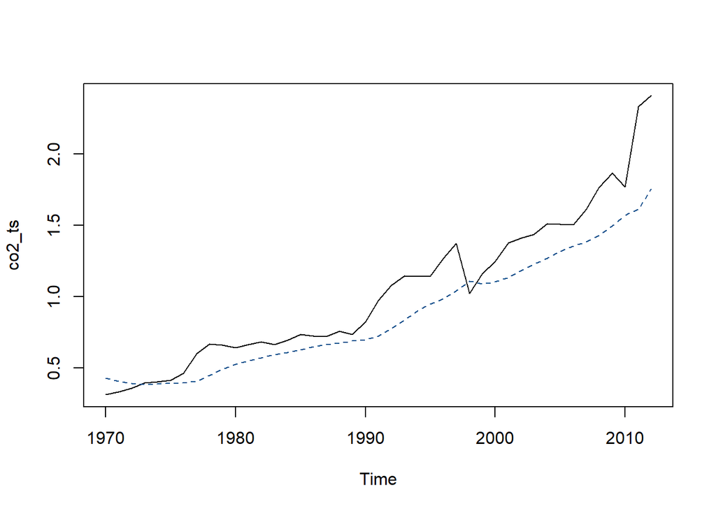

```r
plot(co2_ts)
lines(co2_ets$fitted, lty=2, col="dodgerblue4")
```

It seems like our earlier suspicion was right - it didn’t seem to adequately “capture” the trend in our data.

**Discussion:** It looks like `model="ANN"` isn’t the right model specification for our time series. There exist an additive trend component that wasn’t considered. How would you change the following code?

```r
co2_ets<- ets(____, model="_____", alpha=0.2)
```

To see if your code works, plot the time series along with your forecasting line and compare to the original plot (the one that systematically under-predicts the value of CO2 in Indonesia). Is your model an improvement?

```r
### plot your new exponential smoothing model below and compare to the plot we created above
```

Reference answer: The forecast under-predicted most of the value because the trend component in our time series wasn’t considered. Let’s change the `model` specification by including an additive trend type:

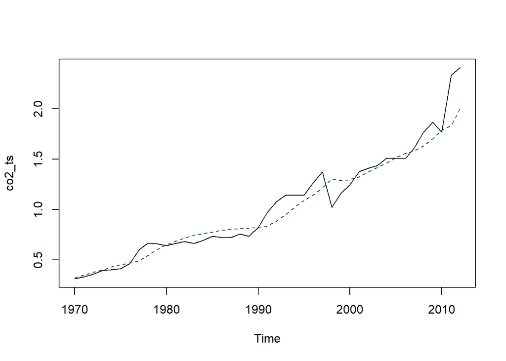

```r
co2_ettrend <- ets(co2_ts, model="AAN", alpha=0.2)
plot(co2_ts)
lines(co2_ettrend$fitted, lty=2, col="dodgerblue4")
```

Another way we can fit a simple exponential smoothing predictive model is by using R’s built-in `HoltWinters()` function, setting `FALSE` for the parameters `beta` and `gamma` in the function call. The `beta` and `gamma` parameters are used for Holt’s exponential smoothing, or Holt-Winters exponential smoothing, which we will discuss in great details later in later sections of the coursebook. For now, let’s call `HoltWinters()` on our co2 emission time series.

The `HoltWinters()` function will return a list variable that contains several named elements, which we will discuss:

```r
co2_hw <- HoltWinters(co2_ts, beta=F, gamma=F)
co2_hw
```

```
## Holt-Winters exponential smoothing without trend and without seasonal component.
##
## Call:
## HoltWinters(x = co2_ts, beta = F, gamma = F)
##
## Smoothing parameters:
##  alpha: 0.9999546
##  beta : FALSE
##  gamma: FALSE
##
## Coefficients:
##       [,1]
## a 2.408917
```

Notice that as we set `beta=FALSE` the time series is assumed to have no trend; `gamma=FALSE` indicates that the time series should be smoothed without consideration of a seasonal component.

Since there is a prior knowledge that our time series does in fact contain a trend component, if you remove `beta=F` from the function call and run the plot below again, you’ll see that we obtain a slightly better estimate. For now, understand that the `beta` represents the coefficient for the trend component in our time series - we’ll look at this with greater attention later.

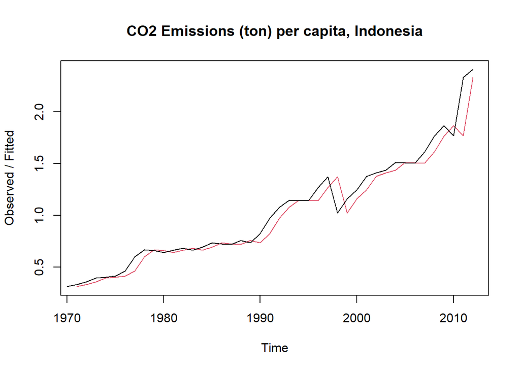

```r
plot(co2_hw, main="CO2 Emissions (ton) per capita, Indonesia")
```

I’ve created another exponential smoothing model on `rain_ts`, and store it under the variable `rain_hw`. Print `rain_hw` and compare it to the output from printing `co2_hw`.

```r
rain_hw <- HoltWinters(rain_ts, beta=F, gamma=F)
```

**Discussion:** Compare the output and pay special attention to the estimated coefficient of the alpha parameter. Recall from earlier sections (line ~470) that:

> If $\alpha$ is small (i.e, close to 0), more weight is given to observations from the more distant past. If $\alpha$ is large (i.e, close to 1), more weight is given to the more recent observations.

Between the CO2 emission and rainfall time series, which has a alpha that is closer to 0? An alpha close to 0 indicates that the forecasts are based on both recent observations and less recent observations while an alpha close to 1 indicates that more weight is given to the more recent observations.